# DESeq_libraries8-11

Rmd to go through `DESeq2` pipeline. Will perform some DEG analyses.

Libraries 8-11 info:  
(These were used in the 02-DeSeq-Temperature.Rmd comparing elevated and decreased)  
They are all pooled samples:  
8 –> Day 2, infected, decreased temperature  
9 –> Day 2, uninfected, decreased temperature  
10 –> Day 2, infected, elevated temperature  
11 –> Day 2, uninfected, elevated temperature

```r
library(DESeq2)
library(tidyverse)
```

```r
library(pheatmap)
library(RColorBrewer)
```

Read in un-normalized counts:  
FROM TRANSCRIPTOME V. 3.1

```r
pooldf <- read.table("../analyses/kallisto-0618.isoform.counts.matrix", header = T, sep = "\t")
rownames(pooldf) <- pooldf$X
pooldf <- pooldf[,-1]
head(pooldf)
```

```
##                           X380822_cold_uninfected X380823_cold_infected
## TRINITY_DN26062_c0_g1_i3                        0               1.83333
## TRINITY_DN37237_c0_g1_i2                        0               0.00000
## TRINITY_DN1988_c1_g1_i30                        0               0.00000
## TRINITY_DN20762_c0_g1_i11                       0               0.00000
## TRINITY_DN9988_c0_g1_i51                        0               0.00000
## TRINITY_DN33404_c0_g1_i2                       12               0.00000
##                           X380824_warm_uninfected X380825_warm_infected
## TRINITY_DN26062_c0_g1_i3                        0               13.3333
## TRINITY_DN37237_c0_g1_i2                        0                8.0000
## TRINITY_DN1988_c1_g1_i30                        0                0.0000
## TRINITY_DN20762_c0_g1_i11                       0               24.8971
## TRINITY_DN9988_c0_g1_i51                        0                0.0000
## TRINITY_DN33404_c0_g1_i2                        0                0.0000
```

Rename columns so I know which samples are infected and which are uninfected:

```r
colnames(pooldf) <- c("uninfected_cold", "infected_cold", "uninfected_warm", "infected_warm")
head(pooldf)
```

```
##                           uninfected_cold infected_cold uninfected_warm
## TRINITY_DN26062_c0_g1_i3                0       1.83333               0
## TRINITY_DN37237_c0_g1_i2                0       0.00000               0
## TRINITY_DN1988_c1_g1_i30                0       0.00000               0
## TRINITY_DN20762_c0_g1_i11               0       0.00000               0
## TRINITY_DN9988_c0_g1_i51                0       0.00000               0
## TRINITY_DN33404_c0_g1_i2               12       0.00000               0
##                           infected_warm
## TRINITY_DN26062_c0_g1_i3        13.3333
## TRINITY_DN37237_c0_g1_i2         8.0000
## TRINITY_DN1988_c1_g1_i30         0.0000
## TRINITY_DN20762_c0_g1_i11       24.8971
## TRINITY_DN9988_c0_g1_i51         0.0000
## TRINITY_DN33404_c0_g1_i2         0.0000
```

ROUND INTEGERS UP:

```r
pooldf <- round(pooldf,0)
head(pooldf)
```

```
##                           uninfected_cold infected_cold uninfected_warm
## TRINITY_DN26062_c0_g1_i3                0             2               0
## TRINITY_DN37237_c0_g1_i2                0             0               0
## TRINITY_DN1988_c1_g1_i30                0             0               0
## TRINITY_DN20762_c0_g1_i11               0             0               0
## TRINITY_DN9988_c0_g1_i51                0             0               0
## TRINITY_DN33404_c0_g1_i2               12             0               0
##                           infected_warm
## TRINITY_DN26062_c0_g1_i3             13
## TRINITY_DN37237_c0_g1_i2              8
## TRINITY_DN1988_c1_g1_i30              0
## TRINITY_DN20762_c0_g1_i11            25
## TRINITY_DN9988_c0_g1_i51              0
## TRINITY_DN33404_c0_g1_i2              0
```

## Get DEGs based on infection (not including temperature as part of the design)

Modeled after what was done in DESeq-infection.Rmd:

```r
#colData <- data.frame(condition=factor(c("uninfected", "infected", "uninfected", "infected")),
#                             type=factor(rep("paired-end", 4)))
#rownames(colData) <- colnames(pooldf)
#dds <- DESeqDataSetFromMatrix(countData = pooldf,
#                                     colData = colData,
#                                     design = ~ condition)
```

```r
#dds <- DESeq(dds)
#res <- results(dds)
#res <- res[order(rownames(res)), ]
```

```r
#head(res)
```

```r
# Count number of hits with adjusted p-value less then 0.05
#dim(res[!is.na(res$padj) & res$padj <= 0.05, ])
```

```r
#infection_fig <- res
# The main plot
#plot(infection_fig$baseMean, infection_fig$log2FoldChange, pch=20, cex=0.45, ylim=c(-15, 15), log="x", col="darkgray",
     #main="Infection Status  (pval </= 0.05)",
#     xlab="mean of normalized counts",
#     ylab="Log2 Fold Change")
# Getting the significant points and plotting them again so they're a different color
#infection_fig.sig <- res[!is.na(res$padj) & res$padj <= 0.05, ]
#points(infection_fig.sig$baseMean, infection_fig.sig$log2FoldChange, pch=20, cex=0.45, col="red")
# 2 FC lines
#abline(h=c(-1,1), col="blue")
```

# Get DEGs based on infection with temperature as part of the design:

Taking temperature exposure into account!!  
From Multi-factor designs section of:  
http://bioconductor.org/packages/release/bioc/vignettes/DESeq2/inst/doc/DESeq2.html#multi-factor-designs

```r
deseq2.colData <- data.frame(condition=factor(c("uninfected", "infected", "uninfected", "infected")),
                             type=factor(rep("paired-end", 4)),
                             temperature=factor(c("decreased", "decreased", "elevated", "elevated")))
rownames(deseq2.colData) <- colnames(pooldf)
deseq2.dds <- DESeqDataSetFromMatrix(countData = pooldf,
                                     colData = deseq2.colData,
                                     design = ~ condition + temperature)
```

Check levels of temperature and condition (infection status)

```r
levels(deseq2.dds$temperature)
```

```
## [1] "decreased" "elevated"
```

```r
levels(deseq2.dds$condition)
```

```
## [1] "infected"   "uninfected"
```

`DESeq2` automatically puts the levels in alphabetical order and the first listed level is the reference level for the factor.

We want uninfected to be the reference.

```r
deseq2.dds$condition = relevel(deseq2.dds$condition, "uninfected")
levels(deseq2.dds$condition)
```

```
## [1] "uninfected" "infected"
```

Cool.

The following will pull the results from `condition` (infection status) because that is our variable of interest. This tells us how temperature contributes to the infection DEGs

```r
design(deseq2.dds) <- formula(~ temperature + condition)
deseq2.dds <- DESeq(deseq2.dds)
```

Access results:

```r
deseq2.res <- results(deseq2.dds)
head(deseq2.res)
```

```
## log2 fold change (MLE): condition infected vs uninfected
## Wald test p-value: condition infected vs uninfected
## DataFrame with 6 rows and 6 columns
##                                   baseMean    log2FoldChange            lfcSE
##                                  <numeric>         <numeric>        <numeric>
## TRINITY_DN26062_c0_g1_i3  3.50579917886673  4.99833229702858  4.8063098565747
## TRINITY_DN37237_c0_g1_i2  1.81689736554866  3.06356324762174 4.88663852591669
## TRINITY_DN1988_c1_g1_i30                 0                NA               NA
## TRINITY_DN20762_c0_g1_i11 5.67780426733955  3.91818508125919 4.79574946801042
## TRINITY_DN9988_c0_g1_i51                 0                NA               NA
## TRINITY_DN33404_c0_g1_i2  3.18301320509335 -3.24671974352447  4.8486211793775
##                                         stat            pvalue      padj
##                                    <numeric>         <numeric> <numeric>
## TRINITY_DN26062_c0_g1_i3    1.03995215585013 0.298362129320395        NA
## TRINITY_DN37237_c0_g1_i2   0.626926512238193   0.5307074075499        NA
## TRINITY_DN1988_c1_g1_i30                  NA                NA        NA
## TRINITY_DN20762_c0_g1_i11  0.817012045227771 0.413921544543169        NA
## TRINITY_DN9988_c0_g1_i51                  NA                NA        NA
## TRINITY_DN33404_c0_g1_i2  -0.669617118642646 0.503101898510371        NA
```

```r
summary(deseq2.res)
```

```
##
## out of 57109 with nonzero total read count
## adjusted p-value < 0.1
## LFC > 0 (up)       : 511, 0.89%
## LFC < 0 (down)     : 72, 0.13%
## outliers [1]       : 0, 0%
## low counts [2]     : 35810, 63%
## (mean count < 10)
## [1] see 'cooksCutoff' argument of ?results
## [2] see 'independentFiltering' argument of ?results
```

```r
# Count number of hits with adjusted p-value less then 0.05
dim(deseq2.res[!is.na(deseq2.res$padj) & deseq2.res$padj <= 0.05, ])
```

```
## [1] 408   6
```

408

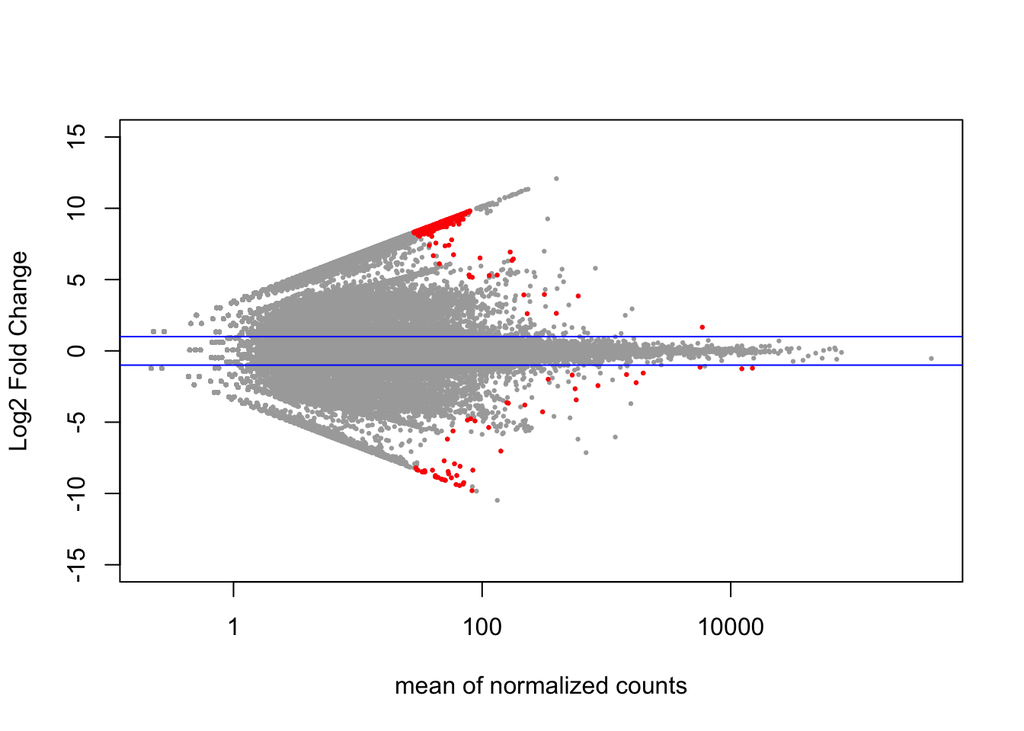

```r
inf <- deseq2.res
# The main plot
plot(inf$baseMean, inf$log2FoldChange, pch=20, cex=0.45, ylim=c(-15, 15), log="x", col="darkgray",
     #main="Infection Status  (pval </= 0.05)",
     xlab="mean of normalized counts",
     ylab="Log2 Fold Change")
# Getting the significant points and plotting them again so they're a different color
inf.sig <- deseq2.res[!is.na(deseq2.res$padj) & deseq2.res$padj <= 0.05, ]
points(inf.sig$baseMean, inf.sig$log2FoldChange, pch=20, cex=0.45, col="red")
# 2 FC lines
abline(h=c(-1,1), col="blue")
```

```r
#write.table(inf.sig, "../analyses/DEGlist-infection_temp-libs8-11.tab", sep = "\t", row.names = T, quote = FALSE, col.names = TRUE)
```

Already wrote out, so I’m commenting above script out.

# Now I need to figure out what these results mean: how exactly does temperature impact DEGs based on infection?

In the multifactor section of the `DESeq2` manual:  
The contrast argument of the function *results* needs a character vector of three componenets: the name of the variable (in this case “temperature”), and the name of the factor level for the numerator of the log2 ratio (elevated) and the denominator (decreased)

A **contrast** is a linear combination of estimated log2 fold changes. Can be used to test if differences between groups are equal to zero.

```r
resultsNames(deseq2.dds)
```

```
## [1] "Intercept"                         "temperature_elevated_vs_decreased"
## [3] "condition_infected_vs_uninfected"
```

```r
deseq2.resTemp <- results(deseq2.dds,
                          contrast = c("temperature", "elevated",  "decreased"))
head(deseq2.resTemp)
```

```
## log2 fold change (MLE): temperature elevated vs decreased
## Wald test p-value: temperature elevated vs decreased
## DataFrame with 6 rows and 6 columns
##                                   baseMean    log2FoldChange            lfcSE
##                                  <numeric>         <numeric>        <numeric>
## TRINITY_DN26062_c0_g1_i3  3.50579917886673  1.12934559541216 4.79051523203324
## TRINITY_DN37237_c0_g1_i2  1.81689736554866  2.71692046218085 4.88663909416771
## TRINITY_DN1988_c1_g1_i30                 0                NA               NA
## TRINITY_DN20762_c0_g1_i11 5.67780426733955  3.57156486029123  4.7957500185273
## TRINITY_DN9988_c0_g1_i51                 0                NA               NA
## TRINITY_DN33404_c0_g1_i2  3.18301320509335 -3.59335561493503 4.84862060960337
##                                         stat            pvalue      padj
##                                    <numeric>         <numeric> <numeric>
## TRINITY_DN26062_c0_g1_i3   0.235746165226749 0.813629644648315        NA
## TRINITY_DN37237_c0_g1_i2   0.555989589127534 0.578217971828952        NA
## TRINITY_DN1988_c1_g1_i30                  NA                NA        NA
## TRINITY_DN20762_c0_g1_i11  0.744735410831111 0.456431687758961        NA
## TRINITY_DN9988_c0_g1_i51                  NA                NA        NA
## TRINITY_DN33404_c0_g1_i2  -0.741108843991195 0.458627447663844        NA
```

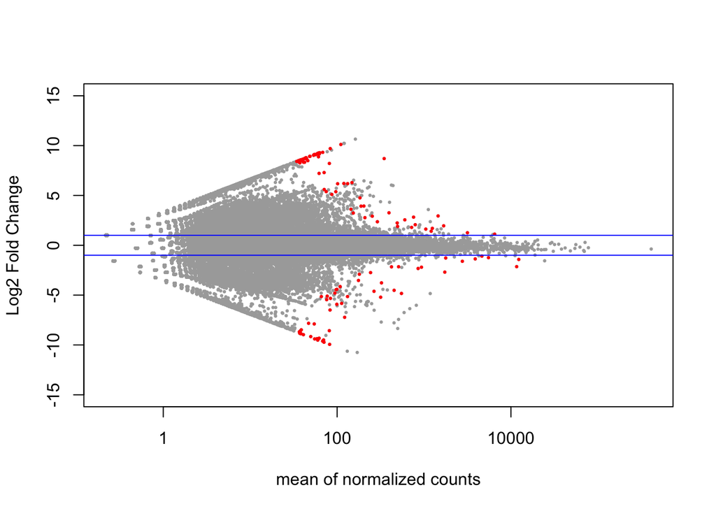

```r
tmp <- deseq2.resTemp
# The main plot
plot(tmp$baseMean, tmp$log2FoldChange, pch=20, cex=0.45, ylim=c(-15, 15), log="x", col="darkgray",
     #main="Infection Status  (pval </= 0.05)",
     xlab="mean of normalized counts",
     ylab="Log2 Fold Change")
# Getting the significant points and plotting them again so they're a different color
tmp.sig <- deseq2.resTemp[!is.na(deseq2.resTemp$padj) & deseq2.resTemp$padj <= 0.05, ]
points(tmp.sig$baseMean, tmp.sig$log2FoldChange, pch=20, cex=0.45, col="red")
# 2 FC lines
abline(h=c(-1,1), col="blue")
```

```r
# Count number of hits with adjusted p-value less then 0.05
dim(deseq2.resTemp[!is.na(deseq2.resTemp$padj) & deseq2.resTemp$padj <= 0.05, ])
```

```
## [1] 123   6
```

123

```r
summary(deseq2.resTemp)
```

```
##
## out of 57109 with nonzero total read count
## adjusted p-value < 0.1
## LFC > 0 (up)       : 107, 0.19%
## LFC < 0 (down)     : 91, 0.16%
## outliers [1]       : 0, 0%
## low counts [2]     : 40153, 70%
## (mean count < 16)
## [1] see 'cooksCutoff' argument of ?results
## [2] see 'independentFiltering' argument of ?results
```

```r
#write.table(tmp.sig, "../analyses/DEGlist-contrast_temp-libs8-11.tab", sep = "\t", row.names = T, quote = FALSE, col.names = TRUE)
```

Already wrote out, so I’m commenting above script out.

## Notes:

From https://www.bioconductor.org/help/course-materials/2015/LearnBioconductorFeb2015/B02.1.1_RNASeqLab.html#de in section “multiple testing”:  
- apparently I should be using a padj of 0.1 cut-off instead of 0.05 ..???